# scmamp: Statistical Comparison of Multiple Algorithms in Multiple Problems

Comparing the results obtained by two or more algorithms in a set of problems is a central task in areas such as machine learning or optimization. Drawing conclusions from these comparisons may require the use of statistical tools such as hypothesis testing. There are some interesting papers that cover this topic. In this manuscript we present *scmamp*, an R package aimed at being a tool that simplifies the whole process of analyzing the results obtained when comparing algorithms, from loading the data to the production of plots and tables.

Borja Calvo (Department of Computer Science and Artificial Intelligence, University of the Basque Country (UPV/EHU)) , Guzmán Santafé (Department of Statistics and Operations Research, Public University of Navarre)  
2015-11-26

Comparing the performance of different algorithms is an essential step in many research and practical computational works. When new algorithms are proposed, they have to be compared with the state of the art. Similarly, when an algorithm is used for a particular problem, its performance with different sets of parameters has to be compared, in order to tune them for the best results.

When the differences are very clear (e.g., when an algorithm is the best in all the problems used in the comparison), the direct comparison of the results may be enough. However, this is an unusual situation and, thus, in most situations a direct comparison may be misleading and not enough to draw sound conclusions; in those cases, the statistical assessment of the results is advisable.

The statistical comparison of algorithms in the context of machine learning has been covered in several papers. In particular, the tools implemented in this package are those presented in (Demšar 2006; García and Herrera 2008; García et al. 2010). Another good review that covers, among other aspects, the statistical assessment of the results in the context of supervised classification can be found in (Santafé et al. 2015).

## 1 Existing tools

Some of the methods presented in the referred papers are well known procedures that are included in classical statistics tools. As an example, *p-value* correction methods such as Holm (Holm 1979) or omnibus tests such as Friedman’s (Friedman 1937) are implemented in R’s base package. However, other methods are neither so well known nor trivial to implement. Worth highlighting is Bergmann and Hommel’s procedure (Bergmann and Hommel 1988) to correct the *p-values* when all the algorithms are compared pair-wise (see García and Herrera 2008 2681).

There are tools that implement some of the methods included in this package. The first one is KEEL (Alcalá-Fdez et al. 2008), a Java toolbox that includes a module for the statistical assessment of the results obtained in a given experiment. However, although it can be used independently from the rest of the toolbox, its GUI offers only a limited combination of methods and any other analysis requires programming within Java.

As an alternative to the KEEL GUI, STATService 2.0 (Parejo et al. 2012) provides a web service to perform statistical analysis of multiple algorithms using KEEL’s code. Along the same lines we have STAC (Rodríguez-Fdez et al. 2015), a Python web service that allows running different types of parametric and non-parametric tests using a simple interface and its own implementation of the methods.

The goal of [*scmamp*](https://CRAN.R-project.org/package=scmamp) is to provide a simple pipeline that allows any researcher to load their complete set of results, analyze them and produce the material needed for publication (tables and plots).

Under some circumstances we may be interested in analyzing the results in different groups of problems. An example of such a situation are the results presented in (Blum et al. 2015), where the behavior of a set of algorithms was tested in problems of different size and complexity[^1]. In order to deal with these kinds of problems, conversely to other existing tools, the package offers the possibility of subsetting the results, which can be handy when the problems can be subdivided into different groups (e.g., based on their size).

Another advantage of the *scmamp* package over other existing implementations is that the functions that perform the analyses accept additional user-defined test and correction functions, increasing the flexibility of the analysis. Moreover, all the correction methods included in the *stats* package through the `p.adjust` function can be directly used in the *scmamp* package.

Finally, we mention that although KEEL and STATService generate tables to be directly used in publications, they do not generate plots. In our package we have included two functions to graphically represent the results of the comparison. Moreover, performing the analysis in R allows the user to easily create his/her own plots.

## 2 Brief overview of the statistical tests and general recommendations

Several publications (Demšar 2006; García and Herrera 2008; García et al. 2010; Santafé et al. 2015) have stated a basic classification of general machine learning scenarios and the associated statistical tests which are appropriate for each situation. This package is mainly focused in the comparison of multiple algorithms in multiple datasets. However, due to the flexibility of the implemented functions, it can also be adapted to other situations. Figure 1 summarizes the most common situations when evaluating machine learning algorithms.

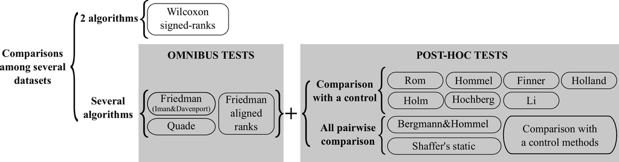

Figure 1: Recommended statistical test for different scenarios.

Comparisons of two algorithms among a set of different problems are common in the literature in order to decide between two competitors. The estimated scores for each algorithm on each problem are independent. However, as they may be obtained from different application domains (or problems with different characteristics), it is highly debatable whether they can be averaged over in order to obtain a meaningful overall estimation of the algorithm’s performance. Consequently, non-parametric methods such as Wilcoxon signed-rank are usually recommended (Demšar 2006).

On the other hand, in order to compare multiple algorithms in multiple problems, the general recommended methodology is as follows. First, we apply an omnibus test to detect if at least one of the algorithms performs differently than the others. Second, if we find a significant difference, then we apply a pair-wise test with the corresponding *post-hoc* correction for multiple comparisons. The Friedman test with Iman and Davemport extension is probably the most popular omnibus test, and it is usually a good choice when comparing more than five different algorithms. By contrast, when comparing five or fewer different algorithms, Friedman aligned ranks and the Quade test are more powerful alternatives (García et al. 2010).

Regarding *post-hoc* tests, the choice depends on the pair-wise comparisons: comparison with a control or all pair-wise comparisons. When comparing all the algorithms with a control, Bonferroni is the most simple but the least powerful procedure and, thus, it is not recomended in practice. By contrast, Hommel and Rom are the two most powerful procedures but they are also more complex than other methods. Alternatively, Finner is a simple procedure and it is the next with the highest power (see García et al. 2010). Nevertheless, except for Bonferroni, in practice there are not very big differences in the power of the *post-hoc* tests. Therefore, in general, Finner’s method is a good choice due to its simplicity and power.

Similarly, when an all pair-wise comparison is conducted, those procedures to perform comparisons with a control can be used. In this case, the Nemenyi’s test is the most simple but less powerful alternative and it is not usually recommended in practice. Alternatively, specific methods for all pair-wise comparison have a higher power. The one with highest power is Bergmann and Hommel, but it is a complex and computationally expensive method. The *scmamp* package optimizes this method for up to nine algorithms by having some pre-computed operations. Therefore, comparing more than nine algorithms with the Bergmann and Hommel procedure is unfeasible in practice. In those situations, Shaffer’s static method or even other more simple procedures such as Finer and Holm are recommended.

## 3 Brief examples

In this section we will illustrate the use of the package in three different situations. For a more detailed discussion on the use of the different functions the reader is referred to the package’s vignettes. These may be accessed with the command `browseVignettes(’scmamp’)`.

The first example of use comes from (García and Herrera 2008). Actually, we will use the set of results presented in that paper, which are included in the package in the variable `data.gh.2008`. These results collect the performance of a number of supervised classification algorithms in a set of 30 datasets. The goal of the study is comparing the different algorithms and determining which outperforms which. For more details, the reader is referred to (García and Herrera 2008).

```r
> library('scmamp')
> head(data.gh.2008)

            C4.5 k-NN(k=1) NaiveBayes Kernel   CN2
Abalone*   0.219     0.202      0.249  0.165 0.261
Adult*     0.803     0.750      0.813  0.692 0.798
Australian 0.859     0.814      0.845  0.542 0.816
Autos      0.809     0.774      0.673  0.275 0.785
Balance    0.768     0.790      0.727  0.872 0.706
Breast     0.759     0.654      0.734  0.703 0.714
```

The goal is analyzing all the pair-wise comparisons. Therefore, the first hypothesis to test is whether all the algorithms perform equally or, in contrast, some of them have a significantly different behavior. Then, all the differences are tested for every pair of algorithms and the resulting *p-values* are corrected. There are different ways to report the results, depending on the *post-hoc* analysis. A very intuitive tool is Demsar’s critical difference plots. Although easy to interpret, these plots are based on the Nemenyi test, which is a very conservative one. There are other alternatives that can be used with more powerful methods (such as Bergmann and Hommel’s correction). In this example we will use the `drawAlgorithmGraph` function which creates a graph based on the *p-values* corrected by any method.

First, we check the differences using the Iman and Davenport omnibus test.

```r
> imanDavenportTest(data.gh.2008)

    Iman Davenport's correction of Friedman's rank sum test

data:  data.gh.2008
Corrected Friedman's chi-squared = 14.3087, df1 = 4, df2 = 116,
p-value = 1.593e-09
```

The *p-value* shown above denotes that there is at least one algorithm that performs differently than the rest and, therefore, we can proceed with the *post-hoc* analysis of the results. There are several alternatives to perform this analysis, but we will focus on two. The first alternative is the Nemenyi test. Although, this test is not a recommended choice in practice since it is very conservative and has a low power, it is shown in this example because its associated plot is quite illustrative.

```r
> nm <- nemenyiTest(data.gh.2008)
> nm

    Nemenyi test

data:  data.gh.2008
Critical difference = 1.1277, k = 5, df = 145
```

```r
> nm$diff.matrix

          C4.5  k-NN(k=1) NaiveBayes    Kernel        CN2
[1,]  0.000000 -1.1500000 -0.1000000 -2.233333 -1.0166667
[2,] -1.150000  0.0000000  1.0500000 -1.083333  0.1333333
[3,] -0.100000  1.0500000  0.0000000 -2.133333 -0.9166667
[4,] -2.233333 -1.0833333 -2.1333333  0.000000  1.2166667
[5,] -1.016667  0.1333333 -0.9166667  1.216667  0.0000000
```

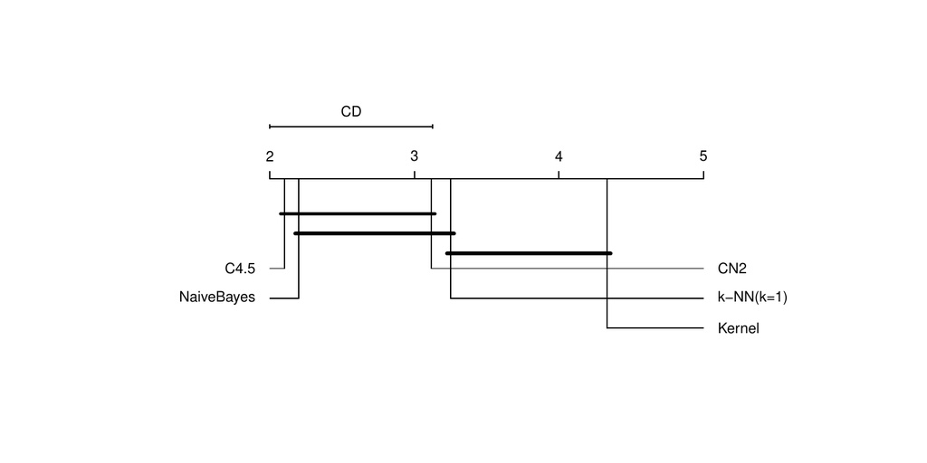

Figure 2: Example of critical difference plot.

This procedure determines the *critical difference*. Any two algorithms whose performance difference is greater that the critical difference are regarded as significantly different. As can be seen in the code above, the differences between every pair of algorithms is stored in the `diff.matrix` element of the result. The Nemenyi test has the advantage of having an associated plot to represent the results of the comparison. This plot can be obtained as follows.

```r
> plotCD(results.matrix = data.gh.2008, alpha = 0.05)
```

The result can be seen in Figure 2. In this plot each algorithm is placed on an axis according to its average ranking. Then, those algorithms that show no significant differences are grouped together using a horizontal line. The plot also shows the size of the critical difference required for considering two algorithm as significantly different.

The second alternative shown in this example is the Friedman *post-hoc* test with Bergmann and Hommel’s correction. Both steps can be carried out in a single line of code.[^2]

```r
> test.res <- postHocTest(data = data.gh.2008, test = 'friedman', correct = 'bergmann')
> test.res

$summary
       C4.5 k-NN(k=1) NaiveBayes    Kernel       CN2
[1,] 0.7797    0.6791     0.7565 0.5693667 0.7285333

$raw.pval
                   C4.5   k-NN(k=1)   NaiveBayes       Kernel         CN2
C4.5                 NA 0.004848763 8.064959e-01 4.486991e-08 0.012763008
k-NN(k=1)  4.848763e-03          NA 1.011233e-02 7.963489e-03 0.743971478
NaiveBayes 8.064959e-01 0.010112334           NA 1.736118e-07 0.024744672
Kernel     4.486991e-08 0.007963489 1.736118e-07           NA 0.002880485
CN2        1.276301e-02 0.743971478 2.474467e-02 2.880485e-03          NA

$corrected.pval
                   C4.5  k-NN(k=1)   NaiveBayes       Kernel        CN2
C4.5                 NA 0.02909258 1.000000e+00 4.486991e-07 0.03828902
k-NN(k=1)  2.909258e-02         NA 3.185396e-02 3.185396e-02 1.00000000
NaiveBayes 1.000000e+00 0.03185396           NA 1.041671e-06 0.03828902
Kernel     4.486991e-07 0.03185396 1.041671e-06           NA 0.01152194
CN2        3.828902e-02 1.00000000 3.828902e-02 1.152194e-02         NA
```

The above code runs the *post-hoc* test, computing the raw *p-value* for each pair of algorithms. These *p-values* are also corrected for multiple testing using Bergman and Hommel’s correction. Additionally, a summary with the average values of each algorithm over all the dataset is obtained.

The package offers two ways of presenting the results obtained in the analysis. On the one hand, we can create a LaTeX table using the function `writeTabular`. This function includes parameters to control several aspects of the table. For more details on its use the reader is referred to the vignette covering the data loading and manipulation. The table generated can be seen in Table 1.

```r
> # LaTeX formated: Significances highlighted in bold
> bold <- test.res$corrected.pval < 0.05
> bold[is.na(bold)] <- FALSE
> writeTabular(table = test.res$corrected.pval, format = 'f', bold = bold,
+              hrule = 0, vrule = 0)

\begin{tabular}{|l|lllll|}
\hline
 & C4.5 & k-NN(k=1) & NaiveBayes & Kernel & CN2 \\
\hline
C4.5 & n/a & {\bf 0.029} & 1.000 & {\bf 0.000} & {\bf 0.038} \\
k-NN(k=1) & {\bf 0.029} & n/a & {\bf 0.032} & {\bf 0.032} & 1.000 \\
NaiveBayes & 1.000 & {\bf 0.032} & n/a & {\bf 0.000} & {\bf 0.038} \\
Kernel & {\bf 0.000} & {\bf 0.032} & {\bf 0.000} & n/a & {\bf 0.012} \\
CN2 & {\bf 0.038} & 1.000 & {\bf 0.038} & {\bf 0.012} & n/a \\
\hline
\end{tabular}
```

Table 1: Example of table generated by the package.

|  | C4.5 | k-NN(k=1) | NaiveBayes | Kernel | CN2 |
| --- | --- | --- | --- | --- | --- |
| C4.5 | n/a | **0.029** | 1.000 | **0.000** | **0.038** |
| k-NN(k=1) | **0.029** | n/a | **0.032** | **0.032** | 1.000 |
| NaiveBayes | 1.000 | **0.032** | n/a | **0.000** | **0.038** |
| Kernel | **0.000** | **0.032** | **0.000** | n/a | **0.012** |
| CN2 | **0.038** | 1.000 | **0.038** | **0.012** | n/a |

On the other hand, the results can be shown in a graph that represents the algorithms that show no significant differences as connected nodes.

```r
> average.ranking <- colMeans(rankMatrix(data.gh.2008))
> drawAlgorithmGraph(pvalue.matrix = test.res$corrected.pval,
+                    mean.value = average.ranking)
```

[output not shown]

```r
> head(data.blum.2015)

  Size Radius FruitFly Shukla Ikeda Turau Rand1 Rand2 FrogCOL FrogMIS
1 1000  0.049      223    213   214   214   214   212     246     226
2 1000  0.049      224    207   209   216   205   211     241     219
3 1000  0.049      219    206   215   214   209   213     243     221
4 1000  0.049      227    208   218   218   215   219     251     230
5 1000  0.049      231    218   210   212   211   217     243     239
6 1000  0.049      230    214   214   208   211   206     246     229
```

The first two columns indicate the size and the density of the random graph while the last eight columns contain the results obtained by each algorithm. Although we could directly use the data loaded in the package, we use this example to briefly show how data can be loaded from one or more files.